# Stat 579 - Homework #8

Urminder Singh

10/23/2018

## Star Wars

1. Download the RMarkdown file with these homework instructions to use as a template for your work. Make sure to replace “Your Name” in the YAML with your name.
2. We are back to a survey collected by FiveThirtyEight. This time we are interested in a survey on Star Wars - the accompanying article is published [here](https://fivethirtyeight.com/features/americas-favorite-star-wars-movies-and-least-favorite-characters/)

```r
library(tidyverse)
library(readr)
starwars <- read_csv("https://raw.githubusercontent.com/fivethirtyeight/data/master/star-wars-survey/StarWars.csv")

# the following lines are necessary to fix the multibyte problem and make proper names
# part of the names:
line1 <- names(starwars)
line2 <- unlist(starwars[1,])
varnames <- paste(line1, line2)
# clean up some of the multibyte characters:
names(starwars) <- enc2native(stringi::stri_trans_general(varnames, "latin-ascii"))

starwars <- starwars[-1,]
head(starwars)
```

```
## # A tibble: 6 x 38
##   `RespondentID N~ `Have you seen ~ `Do you conside~ `Which of the f~
##              <dbl> <chr>            <chr>            <chr>
## 1       3292879998 Yes              Yes              Star Wars: Epis~
## 2       3292879538 No               <NA>             <NA>
## 3       3292765271 Yes              No               Star Wars: Epis~
## 4       3292763116 Yes              Yes              Star Wars: Epis~
## 5       3292731220 Yes              Yes              Star Wars: Epis~
## 6       3292719380 Yes              Yes              Star Wars: Epis~
## # ... with 34 more variables: `X5 Star Wars: Episode II Attack of the
## #   Clones` <chr>, `X6 Star Wars: Episode III Revenge of the Sith` <chr>,
## #   `X7 Star Wars: Episode IV A New Hope` <chr>, `X8 Star Wars: Episode V
## #   The Empire Strikes Back` <chr>, `X9 Star Wars: Episode VI Return of
## #   the Jedi` <chr>, `Please rank the Star Wars films in order of
## #   preference with 1 being your favorite film in the franchise and 6
## #   being your least favorite film. Star Wars: Episode I The Phantom
## #   Menace` <chr>, `X11 Star Wars: Episode II Attack of the Clones` <chr>,
## #   `X12 Star Wars: Episode III Revenge of the Sith` <chr>, `X13 Star
## #   Wars: Episode IV A New Hope` <chr>, `X14 Star Wars: Episode V The
## #   Empire Strikes Back` <chr>, `X15 Star Wars: Episode VI Return of the
## #   Jedi` <chr>, `Please state whether you view the following characters
## #   favorably, unfavorably, or are unfamiliar with him/her. Han
## #   Solo` <chr>, `X17 Luke Skywalker` <chr>, `X18 Princess Leia
## #   Organa` <chr>, `X19 Anakin Skywalker` <chr>, `X20 Obi Wan
## #   Kenobi` <chr>, `X21 Emperor Palpatine` <chr>, `X22 Darth Vader` <chr>,
## #   `X23 Lando Calrissian` <chr>, `X24 Boba Fett` <chr>, `X25
## #   C-3P0` <chr>, `X26 R2 D2` <chr>, `X27 Jar Jar Binks` <chr>, `X28 Padme
## #   Amidala` <chr>, `X29 Yoda` <chr>, `Which character shot first?
## #   Response` <chr>, `Are you familiar with the Expanded Universe?
## #   Response` <chr>, `Do you consider yourself to be a fan of the Expanded
## #   Universe?�� Response` <chr>, `Do you consider yourself
## #   to be a fan of the Star Trek franchise? Response` <chr>, `Gender
## #   Response` <chr>, `Age Response` <chr>, `Household Income
## #   Response` <chr>, `Education Response` <chr>, `Location (Census Region)
## #   Response` <chr>
```

3. How many people responded to the survey? How many people have seen at least one of the movies? Use the variable `Have you seen any of the 6 films in the Star Wars franchise? Response` to answer this question. Only consider responses of participants who have seen at least one of the Star Wars films for the remainder of the homework.

```r
#how many responded
dim(starwars)[1]
```

```
## [1] 1186
```

```r
starwars_yes<-starwars[which(starwars$`Have you seen any of the 6 films in the Star Wars franchise? Response` == 'Yes'),]
#people watched sw
dim(starwars_yes)[1]
```

```
## [1] 936
```

4. Variables `Gender Response` and `Age Response` are two of the demographic variables collected. Use `dplyr` to provide a frequency break down for each variable. Does the result surprise you? Comment. Reorder the levels in the variable `Age Response` from youngest to oldest.

```r
starwars_yes %>% count(`Gender Response`)
```

```
## # A tibble: 3 x 2
##   `Gender Response`     n
##   <chr>             <int>
## 1 Female              397
## 2 Male                423
## 3 <NA>                116
```

```r
starwars_yes %>% count(`Age Response`)
```

```
## # A tibble: 5 x 2
##   `Age Response`     n
##   <chr>          <int>
## 1 > 60             193
## 2 18-29            180
## 3 30-44            207
## 4 45-60            240
## 5 <NA>             116
```

```r
#make factor and arrange levels
starwars_yes$`Age Response`<-factor(starwars_yes$`Age Response`, levels=c("18-29", "30-44", "45-60", "> 60", ""))
levels(starwars_yes$`Age Response`)
```

```
## [1] "18-29" "30-44" "45-60" "> 60"  ""
```

5. Variables 10 through 15 answer the question: “Please rank the Star Wars films in order of preference with 1 being your favorite film in the franchise and 6 being your least favorite film.” for each of the films.

Bring the data set into a long form. Introduce a variable for the star wars episode and the corresponding ranking. Find the average rank for each of the films. Are average ranks different between mens’ and womens’ rankings? On how many responses are the averages based? Show these numbers together with the averages.

```r
starwars_yes[, 10:15]<-sapply(starwars_yes[, 10:15], as.numeric)

xY<-starwars_yes %>% gather(Ep,Rating,colnames(starwars_yes)[10:15])

xY<-xY[which(!is.na(xY$Rating)),] %>% group_by(Ep) %>% mutate(m=mean(Rating))

#MEAN BY MALE AND FEMALE
meanRatings<-xY[which(!is.na(xY$Rating)),] %>% group_by(Ep,`Gender Response`) %>% summarise_at(vars("Rating"), funs(mean, length))
meanRatings
```

```
## # A tibble: 18 x 4
## # Groups:   Ep [?]
##    Ep                                        `Gender Respons~  mean length
##    <chr>                                     <chr>            <dbl>  <int>
##  1 Please rank the Star Wars films in order~ Female            3.43    396
##  2 Please rank the Star Wars films in order~ Male              4.04    423
##  3 Please rank the Star Wars films in order~ <NA>              3.19     16
##  4 X11 Star Wars: Episode II  Attack of the~ Female            3.95    397
##  5 X11 Star Wars: Episode II  Attack of the~ Male              4.22    423
##  6 X11 Star Wars: Episode II  Attack of the~ <NA>              3.75     16
##  7 X12 Star Wars: Episode III  Revenge of t~ Female            4.42    397
##  8 X12 Star Wars: Episode III  Revenge of t~ Male              4.27    422
##  9 X12 Star Wars: Episode III  Revenge of t~ <NA>              4.19     16
## 10 X13 Star Wars: Episode IV  A New Hope     Female            3.54    397
## 11 X13 Star Wars: Episode IV  A New Hope     Male              3.00    423
## 12 X13 Star Wars: Episode IV  A New Hope     <NA>              3.81     16
## 13 X14 Star Wars: Episode V The Empire Stri~ Female            2.57    397
## 14 X14 Star Wars: Episode V The Empire Stri~ Male              2.46    423
## 15 X14 Star Wars: Episode V The Empire Stri~ <NA>              2.56     16
## 16 X15 Star Wars: Episode VI Return of the ~ Female            3.08    397
## 17 X15 Star Wars: Episode VI Return of the ~ Male              3.00    423
## 18 X15 Star Wars: Episode VI Return of the ~ <NA>              3.5      16
```

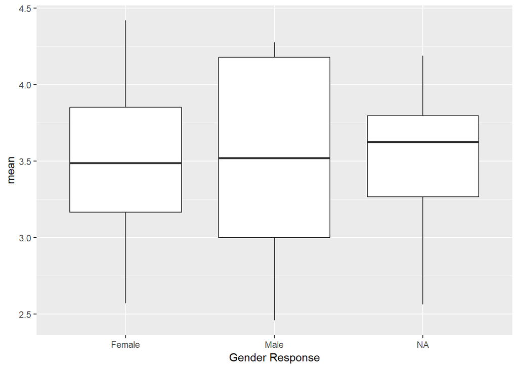

```r
ggplot(data=meanRatings,aes(x=`Gender Response`)) + geom_boxplot(aes(y=mean))
```

For some of the movies male mean is higher than female. For others the trend is opposite. Overall, there is more spread in mean values among the male group.

6. R2 D2 or C-3P0? Which of these two characters is the more popular one? Use responses to variables 25 and 26 to answer this question. Note: first you need to define what you mean by “popularity” based on the available data.

```r
popularity<-starwars_yes[,25:26] %>% gather(Character,pop,colnames(starwars_yes)[25:26])
#remove NA Unfamiliar (N/A)
popularity<-popularity %>% filter(!is.na(pop))%>% filter(!(pop == "Unfamiliar (N/A)"))
#map popularity to scale -2 -1 0 1 2
# very unfavorably Somewhat unfavorably neutral Somewhat favorably Very favorably
unique(popularity$pop)
```

```
## [1] "Very favorably"
## [2] "Somewhat favorably"
## [3] "Neither favorably nor unfavorably (neutral)"
## [4] "Somewhat unfavorably"
## [5] "Very unfavorably"
```

```r
popularity <- popularity %>% mutate(popInt = case_when(pop=='Very unfavorably' ~-2, pop=='very unfavorably' ~-2, pop=='Somewhat unfavorably' ~-1, pop=='Neither favorably nor unfavorably (neutral)' ~0, pop=='Somewhat favorably' ~1, pop=='Very favorably' ~2))

popularity %>% group_by(Character) %>% summarise_at(vars(popInt),mean) %>% arrange(desc(popInt))
```

```
## # A tibble: 2 x 2
##   Character popInt
##   <chr>      <dbl>
## 1 X26 R2 D2   1.57
## 2 X25 C-3P0   1.40
```

I define popularity to be how favorable a character is. I mapped the popularity to a popularity score on a scale of -2 to +2, where -2 is Very unfavorably, -1 is Somewhat unfavorably, 0 is neutral, +1 is Somewhat favorably and +2 is Very favorably. Overall popularity of a character is then the mean of all the scores by the respondents. R2-D2 is more popular than C-3P0.

7. Popularity contest: which of the surveyed characters is the most popular? use the popularity measure you defined in the previous question to evaluate responses for characters 16 through 29. Use an appropriate long form of the data to get to your answer. Visualize the result.

```r
popularity<-starwars_yes[,16:29] %>% gather(Character,pop,colnames(starwars_yes)[16:29])
#remove NA Unfamiliar (N/A)
popularity<-popularity %>% filter(!is.na(pop))%>% filter(!(pop == "Unfamiliar (N/A)"))
#map popularity to scale -2 -1 0 1 2
# very unfavorably Somewhat unfavorably neutral Somewhat favorably Very favorably
unique(popularity$pop)
```

```
## [1] "Very favorably"
## [2] "Somewhat favorably"
## [3] "Neither favorably nor unfavorably (neutral)"
## [4] "Somewhat unfavorably"
## [5] "Very unfavorably"
```

[figure not shown]

```r
popularity <- popularity %>% mutate(popInt = case_when(pop=='Very unfavorably' ~-2, pop=='very unfavorably' ~-2, pop=='Somewhat unfavorably' ~-1, pop=='Neither favorably nor unfavorably (neutral)' ~0, pop=='Somewhat favorably' ~1, pop=='Very favorably' ~2))

meanpopularityAllchars <- popularity %>% group_by(Character) %>% summarise_at(vars(popInt),mean) %>% arrange(desc(popInt))
#rename
meanpopularityAllchars[1,1]<- "Han Solo"
#make factor to avoid reorder
meanpopularityAllchars$Character <- factor(meanpopularityAllchars$Character, levels = meanpopularityAllchars$Character)

ggplot(data=meanpopularityAllchars,aes(x=`Character`,y=popInt,fill=(Character))) + geom_bar(stat = "identity") + theme(axis.text.x = element_text(angle = 90, hjust = 1))
```

The most popular character is Han Solo and least popular is Jar Jar Binks